# R Notebook

```r
knitr::opts_chunk$set(error = TRUE)
library(readr)
#Reading in dataset
#NBARel <- read.csv("/Users/Victor/Desktop/Senior Project/RelativeNBATrends.csv", header = TRUE)
NBARel <- read.csv("./RelativeNBATrends.csv", header = TRUE)
NBA_Team_Records <- read_csv("./NBA_Team_Records.csv")
#Reshaping data from wide format to long format
library(tidyverse)
library(lubridate)
NBATeams <- gather(NBARel, Team, Popularity, AtlantaHawks:WashingtonWizards, factor_key=TRUE)
names(NBATeams)[1] <- "Date"

#Creating new variable indicating month of year for each observation
# MonthNum2 <- substr(as.character(NBATeams$Month), 6,7)
# NBATeams$MonthNum <- MonthNum2

# Make Month a datetime object
NBATeams$Date <- parse_date_time(NBATeams$Date, orders = "ym")
NBATeams$MonthNum <- month(NBATeams$Date)

#Replacing all instances of Popularity scores of "<1" with 0
NBATeams$Popularity<- str_replace(NBATeams$Popularity, "<1","0")

#Setting Popularity variable to be numeric
NBATeams$Popularity <- as.numeric(NBATeams$Popularity)
```

```r
#Calculating mean for each NBA team
aggregate(Popularity ~ Team, NBATeams, mean) %>% arrange(desc(Popularity))
```

| Team | Popularity |
| --- | --- |
| LosAngelesLakers | 8.5934066 |
| GoldenStateWarriors | 7.6978022 |
| ClevelandCavaliers | 6.7307692 |
| BostonCeltics | 4.8516484 |
| MiamiHeat | 4.5549451 |
| ChicagoBulls | 4.0989011 |
| NewYorkKnicks | 3.7362637 |
| SanAntonioSpurs | 3.6318681 |
| HoustonRockets | 2.9065934 |
| OklahomaCityThunder | 2.6373626 |

[output cut: 20 more lines]

From viewing the mean popuarlity score for each team, we see that the teams with the highest average popularity scores since 2004 are the Los Angeles Lakers, Golden State Warriors, and Cleveland Cavaliers. This makes intuitive sense because the Lakers are consistently one of the most popular teams in the league and have one of the largest fanbases. The Cleveland Cavaliers and Golden State Warriors have also been very succesful teams lately, having played each other in the NBA Finals the past 4 years, from 2015-2018.

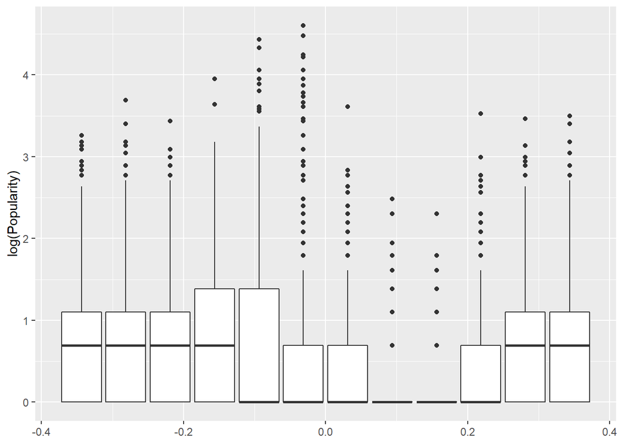

```r
#Boxplot of Popularity score by each month
ggplot(NBATeams, aes(group = month(Date), y = log(Popularity))) + geom_boxplot()
```

Shown above is a boxplot of the log Popularity scores for each month.

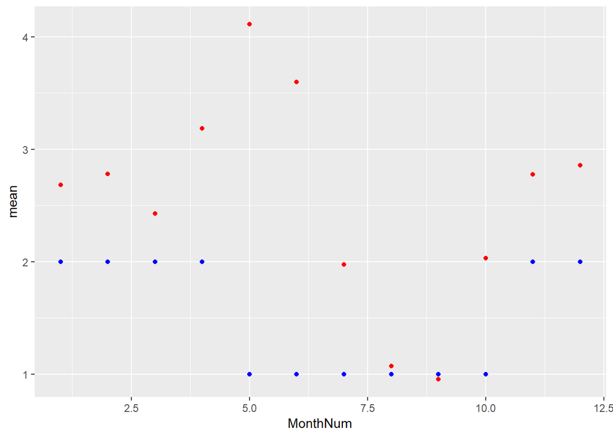

```r
#Scatterplot with mean and median Popularity score by month
#Red = Mean , Blue = Median

NBATeams %>%
  group_by(MonthNum) %>%
  summarize_at(vars(Popularity), funs(mean, median)) %>%
  ggplot() + geom_point(aes(x = MonthNum, y = mean), col = "red") +
  geom_point(aes(x = MonthNum, y = median), col = "blue")
```

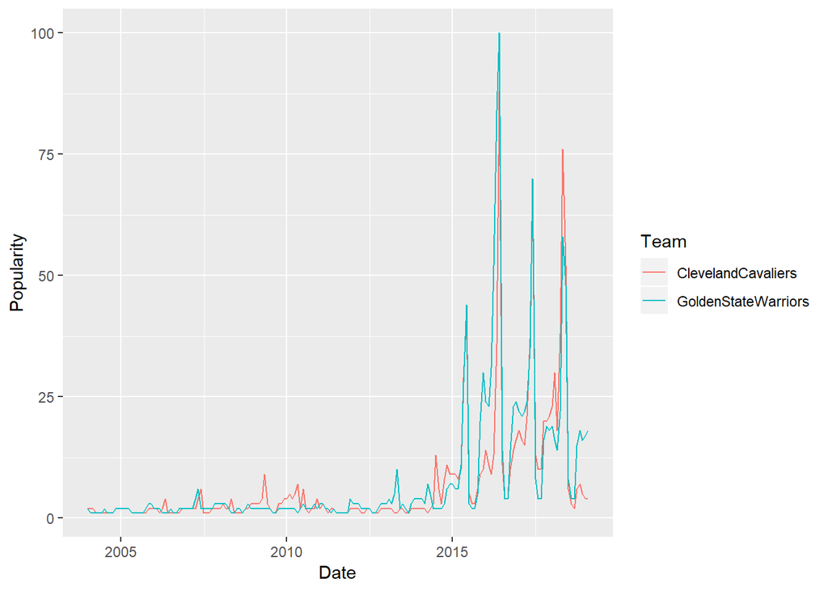

```r
NBATeams %>%
  filter(Team %in% c("ClevelandCavaliers", "GoldenStateWarriors")) %>%
  ggplot(aes(x = Date, y = Popularity, color = Team)) + geom_line()
```

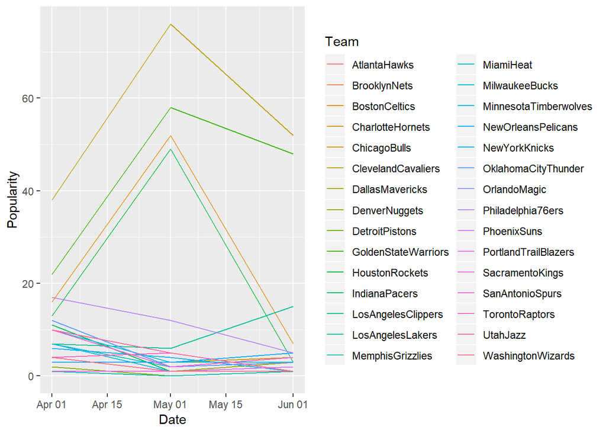

```r
NBATeams %>%
  filter(Date %within% interval("2018-04-01", "2018-06-01")) %>%
  ggplot(aes(x = Date, y = Popularity, color = Team)) + geom_line()
```

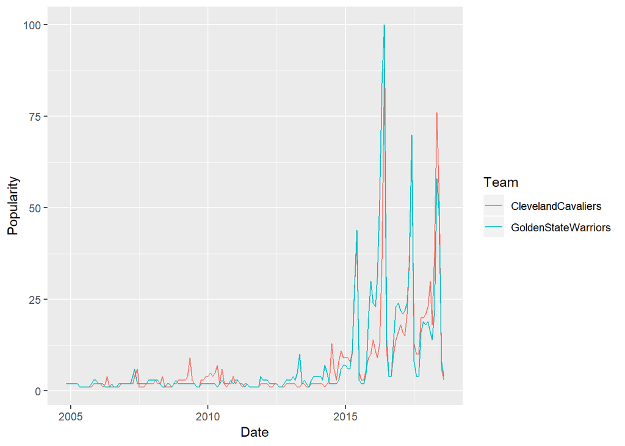

```r
NBATeams %>%
  filter(Date %within% interval("2004-11-01", "2018-08-01") & Team %in% c("ClevelandCavaliers", "GoldenStateWarriors")) %>%
  ggplot(aes(x = Date, y = Popularity, color = Team)) + geom_line()
```

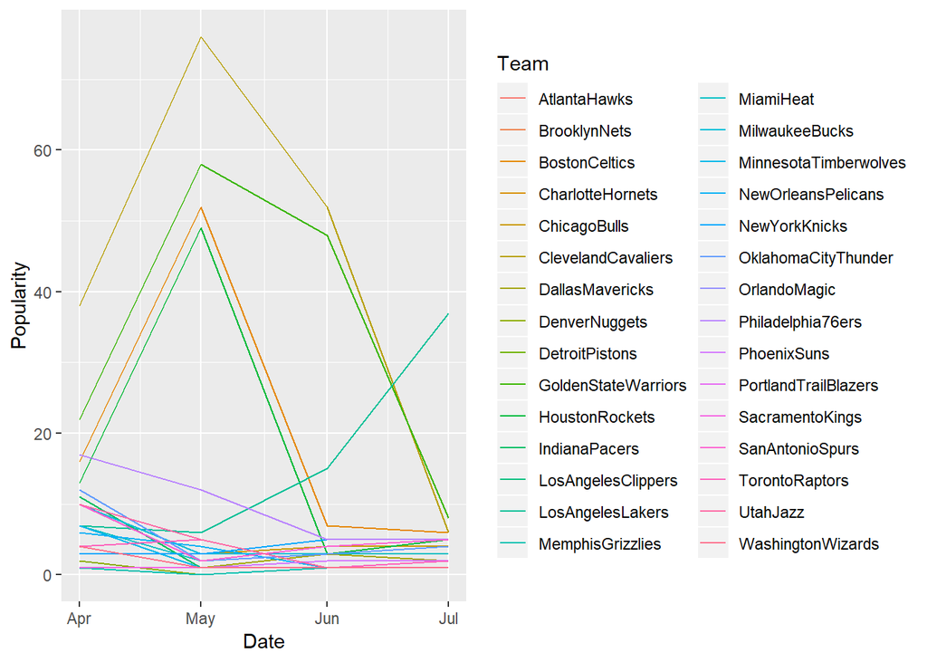

```r
NBATeams %>%
  filter(Date %within% interval("2018-04-01", "2018-07-01")) %>%
  ggplot(aes(x = Date, y = Popularity, color = Team)) + geom_line()
```

In this first plot, we are comparing the popularity scores for the Cleveland Cavaliers and the Golden State Warriors, across all time points. We can see that the popularity scores for both teams never exceeded about 15 until 2015. In 2015 we see a large increase in the popularity score for the Golden State Warriors. We also see large spikes in the popularity scores for both teams in what appears to be the middle of the years for 2016, 2017, and 2018. The Cavaliers and the Warriors played each other in the NBA Finals for all 3 of these years, so this is likely the explanation for the large increase in popularity for these teams.

In this second plot, we are examining the popularity scores for all 30 teams from April 2018 to June 2018. These dates encompass the duration of the 2018 playoffs, so we are hoping this plot can help give us an idea of what teams performed well in the NBA playoffs this year. Here we can see that the Cleveland Cavaliers had the highest popularity score for the entirety of the playoffs, with the Golden State Warriors following closely behind. This makes sense again because these two teams ended playing each other in the NBA Finals yet again. We also see a large cluster of teams near the bottm that have popularity scores that are hardly ever above 10 for these months. These all appear to be teams that did not make the NBA Finals in 2018. Thus, this graph seems to suggest that teams that perform well during the NBA playoffs tend to receive a large increase in search popularity.

```r
basic_model <- lm(Popularity ~ factor(MonthNum) + Team, data = NBATeams)

summary(basic_model)
```

```
##
## Call:
## lm(formula = Popularity ~ factor(MonthNum) + Team, data = NBATeams)
##
## Residuals:
##    Min     1Q Median     3Q    Max
## -8.269 -1.369 -0.192  0.696 91.244
##
## Coefficients:
##                           Estimate Std. Error t value Pr(>|t|)
## (Intercept)                1.41813    0.37671   3.765 0.000169 ***
## factor(MonthNum)2          0.09792    0.28278   0.346 0.729154
## factor(MonthNum)3         -0.25444    0.28745  -0.885 0.376100
## factor(MonthNum)4          0.50111    0.28745   1.743 0.081339 .
## factor(MonthNum)5          1.42778    0.28745   4.967 7.01e-07 ***
## factor(MonthNum)6          0.91444    0.28745   3.181 0.001475 **
## factor(MonthNum)7         -0.70778    0.28745  -2.462 0.013837 *
## factor(MonthNum)8         -1.61000    0.28745  -5.601 2.24e-08 ***
## factor(MonthNum)9         -1.73000    0.28745  -6.018 1.88e-09 ***
## factor(MonthNum)10        -0.65000    0.28745  -2.261 0.023783 *
## factor(MonthNum)11         0.09222    0.28745   0.321 0.748353
## factor(MonthNum)12         0.17222    0.28745   0.599 0.549106
## TeamBrooklynNets           0.15385    0.45923   0.335 0.737630
## TeamBostonCeltics          3.57692    0.45923   7.789 8.04e-15 ***
## TeamCharlotteHornets      -0.04945    0.45923  -0.108 0.914252
## TeamChicagoBulls           2.82418    0.45923   6.150 8.31e-10 ***
## TeamClevelandCavaliers     5.45604    0.45923  11.881  < 2e-16 ***
## TeamDallasMavericks        1.03297    0.45923   2.249 0.024530 *
## TeamDenverNuggets         -0.12088    0.45923  -0.263 0.792389
## TeamDetroitPistons         0.47802    0.45923   1.041 0.297956
## TeamGoldenStateWarriors    6.42308    0.45923  13.987  < 2e-16 ***
## TeamHoustonRockets         1.63187    0.45923   3.554 0.000383 ***
## TeamIndianaPacers          0.03846    0.45923   0.084 0.933256
## TeamLosAngelesClippers     0.54945    0.45923   1.196 0.231566
## TeamLosAngelesLakers       7.31868    0.45923  15.937  < 2e-16 ***
## TeamMemphisGrizzlies      -0.59890    0.45923  -1.304 0.192238
## TeamMiamiHeat              3.28022    0.45923   7.143 1.03e-12 ***
## TeamMilwaukeeBucks         0.32967    0.45923   0.718 0.472862
## TeamMinnesotaTimberwolves -0.23626    0.45923  -0.514 0.606937
## TeamNewOrleansPelicans    -0.58791    0.45923  -1.280 0.200522
## TeamNewYorkKnicks          2.46154    0.45923   5.360 8.66e-08 ***
## TeamOklahomaCityThunder    1.36264    0.45923   2.967 0.003018 **
## TeamOrlandoMagic          -0.31868    0.45923  -0.694 0.487742
## TeamPhiladelphia76ers      0.59341    0.45923   1.292 0.196348
## TeamPhoenixSuns            0.33516    0.45923   0.730 0.465516
## TeamPortlandTrailBlazers   0.19231    0.45923   0.419 0.675405
## TeamSacramentoKings       -0.05495    0.45923  -0.120 0.904767
## TeamSanAntonioSpurs        2.35714    0.45923   5.133 2.95e-07 ***
## TeamTorontoRaptors        -0.59890    0.45923  -1.304 0.192238
## TeamUtahJazz              -0.10989    0.45923  -0.239 0.810887
## TeamWashingtonWizards      0.23626    0.45923   0.514 0.606937
## ---
## Signif. codes:  0 '***' 0.001 '**' 0.01 '*' 0.05 '.' 0.1 ' ' 1
##
## Residual standard error: 4.381 on 5419 degrees of freedom
## Multiple R-squared:  0.2093, Adjusted R-squared:  0.2035
## F-statistic: 35.86 on 40 and 5419 DF,  p-value: < 2.2e-16
```

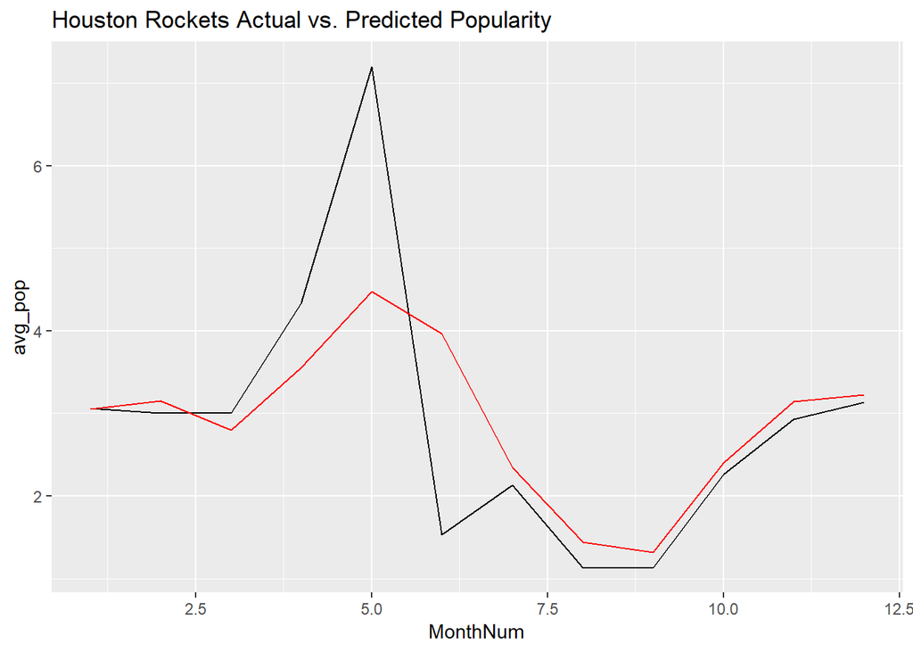

```r
library(modelr)
NBATeams <- NBATeams %>% add_predictions(basic_model)

NBATeams %>%
  filter(Team == "HoustonRockets") %>%
  group_by(MonthNum) %>%
  summarize(avg_pop = mean(Popularity), pred = mean(pred)) %>%
  ggplot() + geom_line(aes(x = MonthNum, y = avg_pop)) + geom_line(aes(x = MonthNum, y = pred), col = "red")  +
  ggtitle("Houston Rockets Actual vs. Predicted Popularity")
```

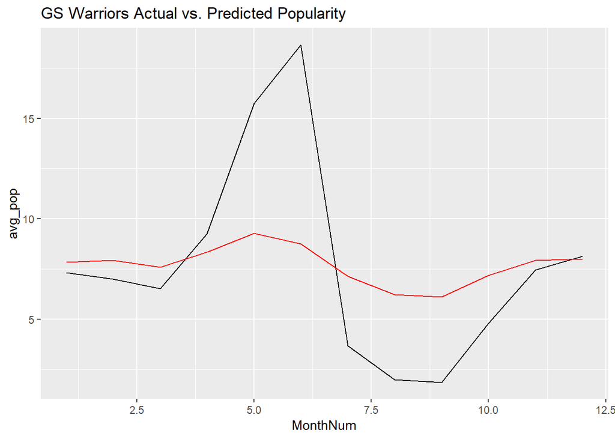

```r
NBATeams %>%
  filter(Team == "GoldenStateWarriors") %>%
  group_by(MonthNum) %>%
  summarize(avg_pop = mean(Popularity), pred = mean(pred)) %>%
  ggplot() + geom_line(aes(x = MonthNum, y = avg_pop)) + geom_line(aes(x = MonthNum, y = pred), col = "red") +
  ggtitle("GS Warriors Actual vs. Predicted Popularity")
```

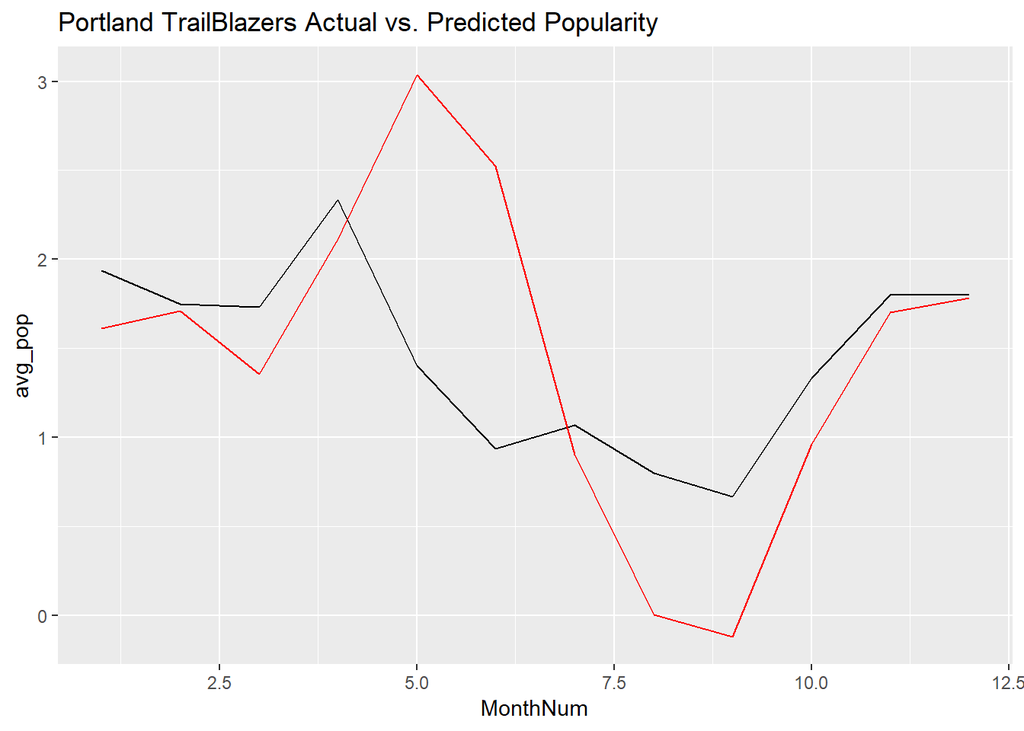

```r
NBATeams %>%
  filter(Team == "PortlandTrailBlazers") %>%
  group_by(MonthNum) %>%
  summarize(avg_pop = mean(Popularity), pred = mean(pred)) %>%
  ggplot() + geom_line(aes(x = MonthNum, y = avg_pop)) + geom_line(aes(x = MonthNum, y = pred), col = "red") +
  ggtitle("Portland TrailBlazers Actual vs. Predicted Popularity")
```

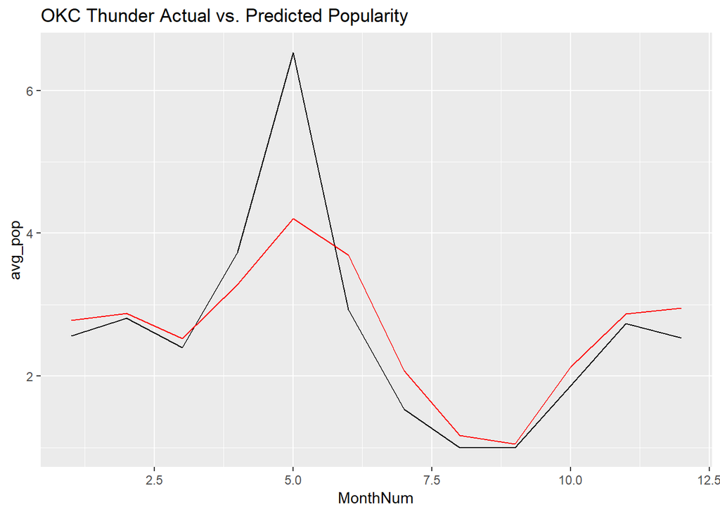

```r
NBATeams %>%
  filter(Team == "OklahomaCityThunder") %>%
  group_by(MonthNum) %>%
  summarize(avg_pop = mean(Popularity), pred = mean(pred)) %>%
  ggplot() + geom_line(aes(x = MonthNum, y = avg_pop)) + geom_line(aes(x = MonthNum, y = pred), col = "red") +
  ggtitle("OKC Thunder Actual vs. Predicted Popularity")
```

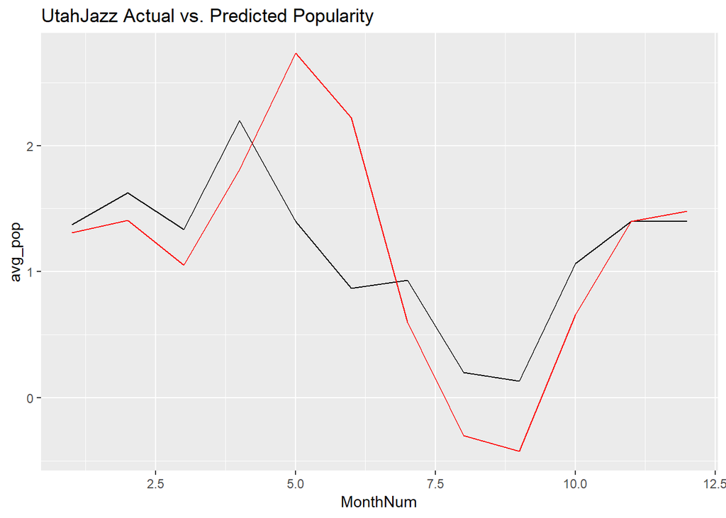

```r
NBATeams %>%
  filter(Team == "UtahJazz") %>%
  group_by(MonthNum) %>%
  summarize(avg_pop = mean(Popularity), pred = mean(pred)) %>%
  ggplot() + geom_line(aes(x = MonthNum, y = avg_pop)) + geom_line(aes(x = MonthNum, y = pred), col = "red") +
  ggtitle("UtahJazz Actual vs. Predicted Popularity")
```

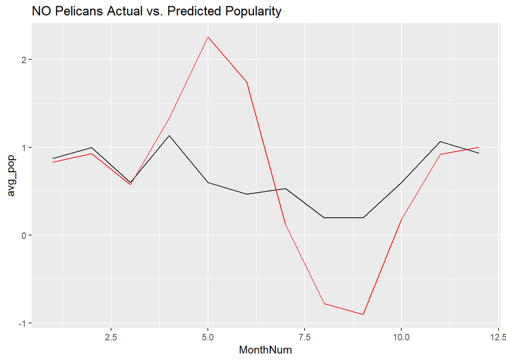

```r
NBATeams %>%
  filter(Team == "NewOrleansPelicans") %>%
  group_by(MonthNum) %>%
  summarize(avg_pop = mean(Popularity), pred = mean(pred)) %>%
  ggplot() + geom_line(aes(x = MonthNum, y = avg_pop)) + geom_line(aes(x = MonthNum, y = pred), col = "red") +
  ggtitle("NO Pelicans Actual vs. Predicted Popularity")
```

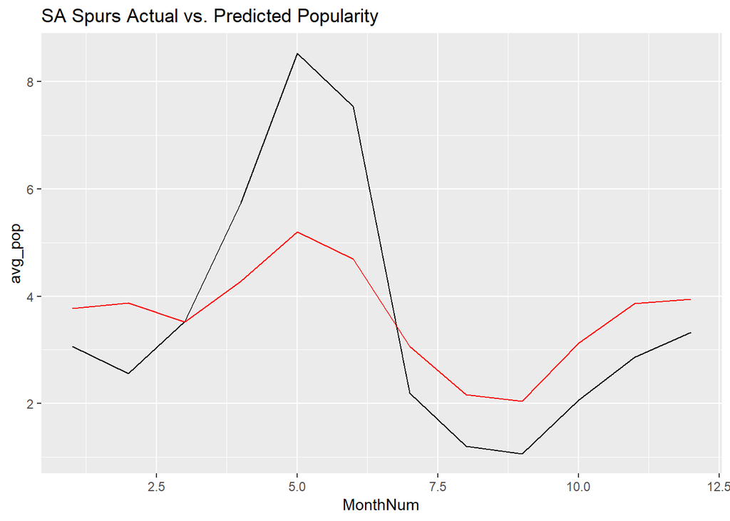

```r
NBATeams %>%
  filter(Team == "SanAntonioSpurs") %>%
  group_by(MonthNum) %>%
  summarize(avg_pop = mean(Popularity), pred = mean(pred)) %>%
  ggplot() + geom_line(aes(x = MonthNum, y = avg_pop)) + geom_line(aes(x = MonthNum, y = pred), col = "red") +
  ggtitle("SA Spurs Actual vs. Predicted Popularity")
```

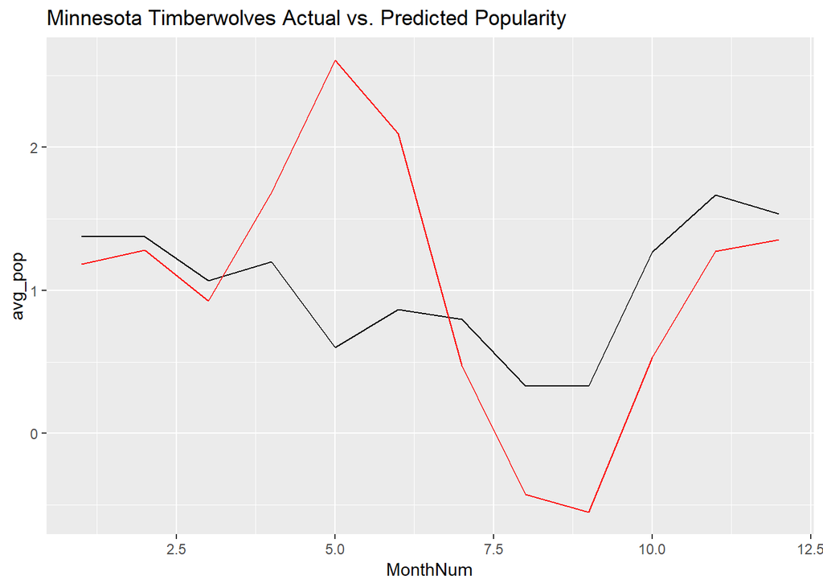

```r
NBATeams %>%
  filter(Team == "MinnesotaTimberwolves") %>%
  group_by(MonthNum) %>%
  summarize(avg_pop = mean(Popularity), pred = mean(pred)) %>%
  ggplot() + geom_line(aes(x = MonthNum, y = avg_pop)) + geom_line(aes(x = MonthNum, y = pred), col = "red") +
  ggtitle("Minnesota Timberwolves Actual vs. Predicted Popularity")
```

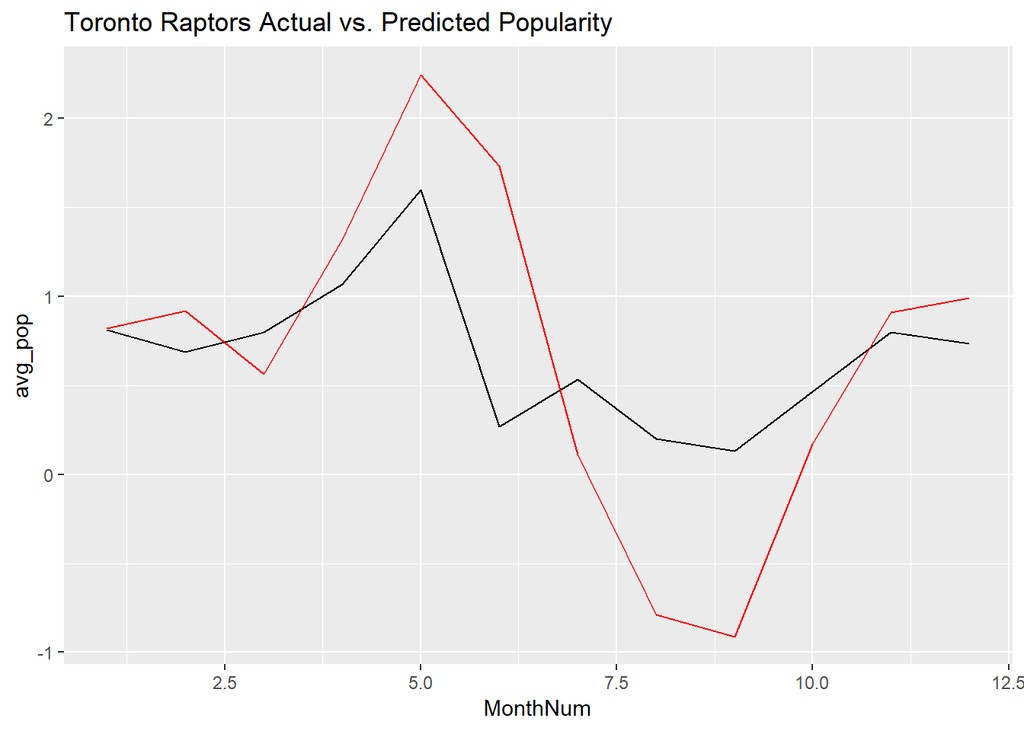

```r
NBATeams %>%
  filter(Team == "TorontoRaptors") %>%
  group_by(MonthNum) %>%
  summarize(avg_pop = mean(Popularity), pred = mean(pred)) %>%
  ggplot() + geom_line(aes(x = MonthNum, y = avg_pop)) + geom_line(aes(x = MonthNum, y = pred), col = "red") +
  ggtitle("Toronto Raptors Actual vs. Predicted Popularity")
```

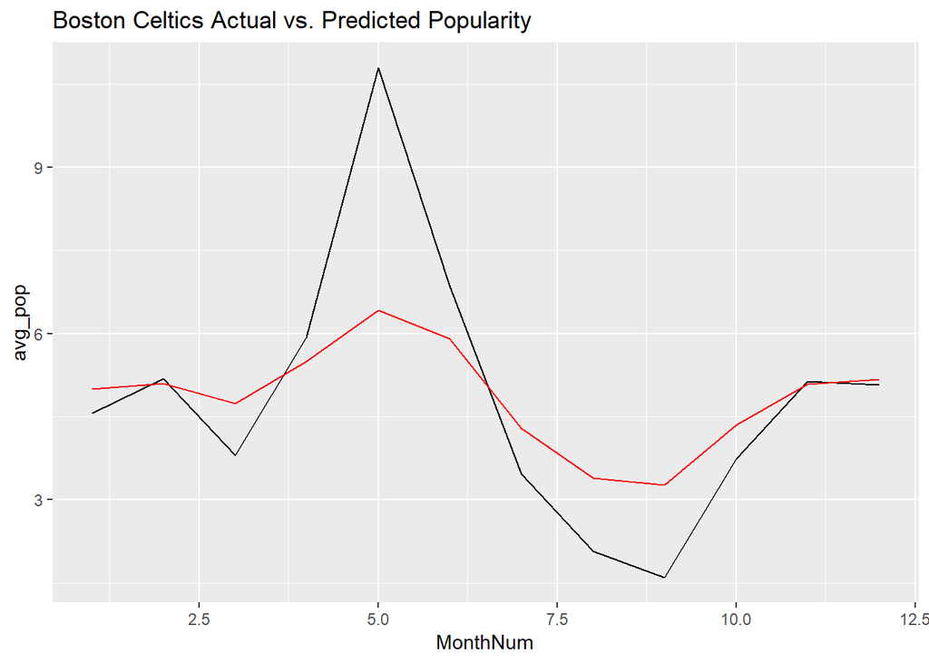

```r
NBATeams %>%
  filter(Team == "BostonCeltics") %>%
  group_by(MonthNum) %>%
  summarize(avg_pop = mean(Popularity), pred = mean(pred)) %>%
  ggplot() + geom_line(aes(x = MonthNum, y = avg_pop)) + geom_line(aes(x = MonthNum, y = pred), col = "red") +
  ggtitle("Boston Celtics Actual vs. Predicted Popularity")
```

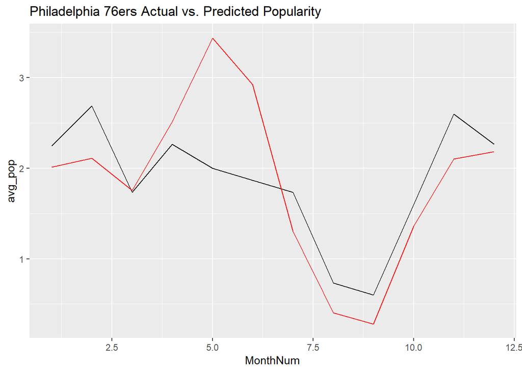

```r
NBATeams %>%
  filter(Team == "Philadelphia76ers") %>%
  group_by(MonthNum) %>%
  summarize(avg_pop = mean(Popularity), pred = mean(pred)) %>%
  ggplot() + geom_line(aes(x = MonthNum, y = avg_pop)) + geom_line(aes(x = MonthNum, y = pred), col = "red") +
  ggtitle("Philadelphia 76ers Actual vs. Predicted Popularity")
```

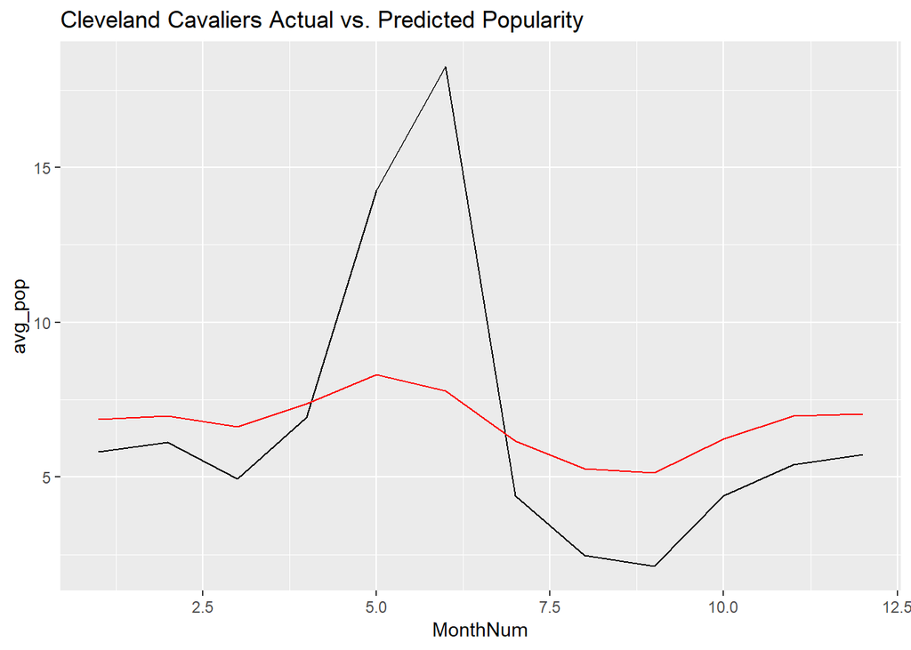

```r
NBATeams %>%
  filter(Team == "ClevelandCavaliers") %>%
  group_by(MonthNum) %>%
  summarize(avg_pop = mean(Popularity), pred = mean(pred)) %>%
  ggplot() + geom_line(aes(x = MonthNum, y = avg_pop)) + geom_line(aes(x = MonthNum, y = pred), col = "red") +
  ggtitle("Cleveland Cavaliers Actual vs. Predicted Popularity")
```

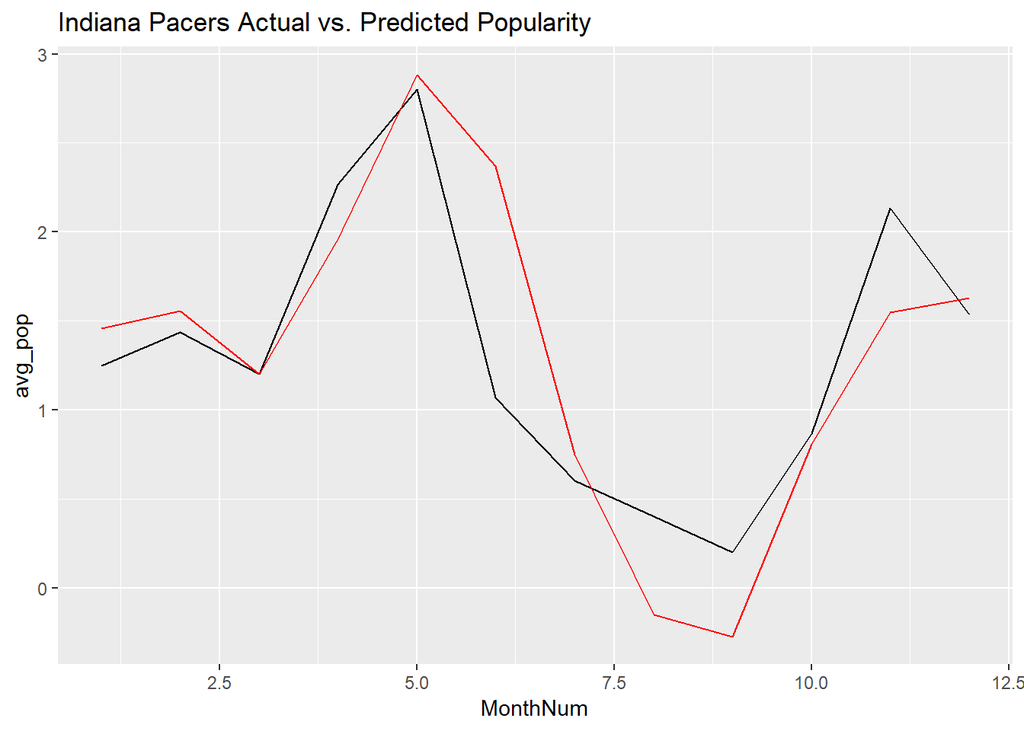

```r
NBATeams %>%
  filter(Team == "IndianaPacers") %>%
  group_by(MonthNum) %>%
  summarize(avg_pop = mean(Popularity), pred = mean(pred)) %>%
  ggplot() + geom_line(aes(x = MonthNum, y = avg_pop)) + geom_line(aes(x = MonthNum, y = pred), col = "red") +
  ggtitle("Indiana Pacers Actual vs. Predicted Popularity")
```

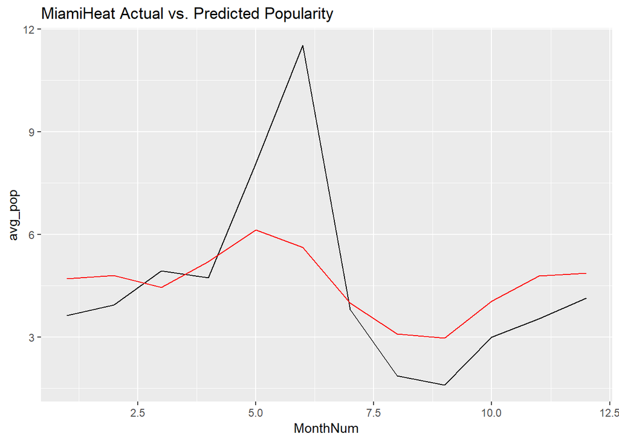

```r
NBATeams %>%
  filter(Team == "MiamiHeat") %>%
  group_by(MonthNum) %>%
  summarize(avg_pop = mean(Popularity), pred = mean(pred)) %>%
  ggplot() + geom_line(aes(x = MonthNum, y = avg_pop)) + geom_line(aes(x = MonthNum, y = pred), col = "red") +
  ggtitle("MiamiHeat Actual vs. Predicted Popularity")
```

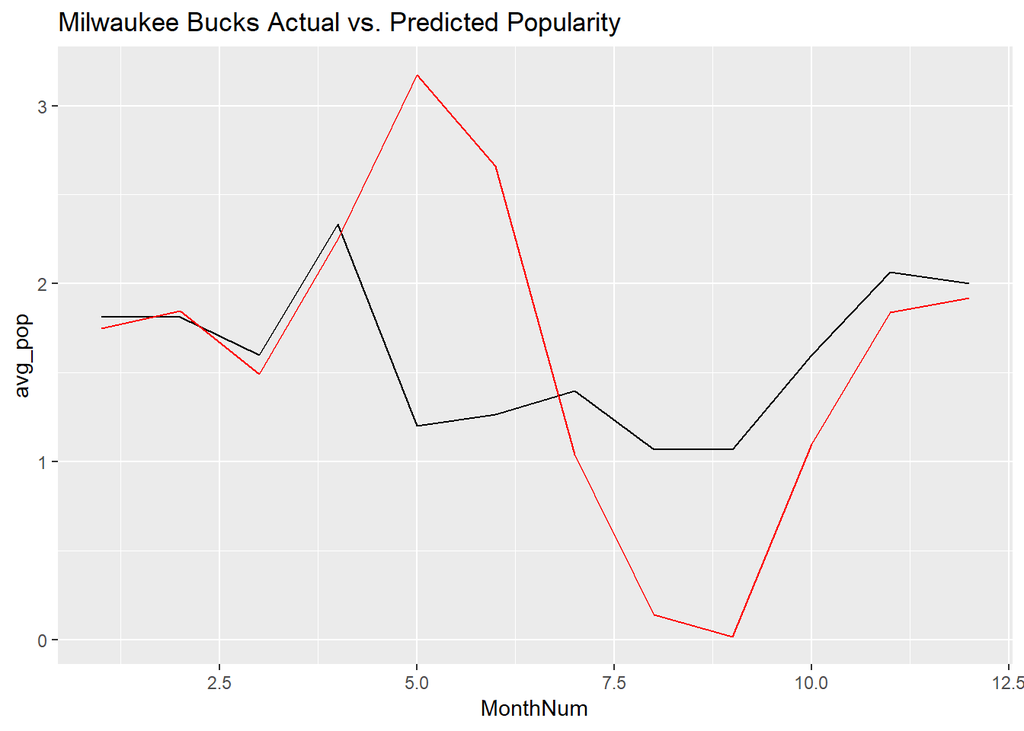

```r
NBATeams %>%
  filter(Team == "MilwaukeeBucks") %>%
  group_by(MonthNum) %>%
  summarize(avg_pop = mean(Popularity), pred = mean(pred)) %>%
  ggplot() + geom_line(aes(x = MonthNum, y = avg_pop)) + geom_line(aes(x = MonthNum, y = pred), col = "red") +
  ggtitle("Milwaukee Bucks Actual vs. Predicted Popularity")
```

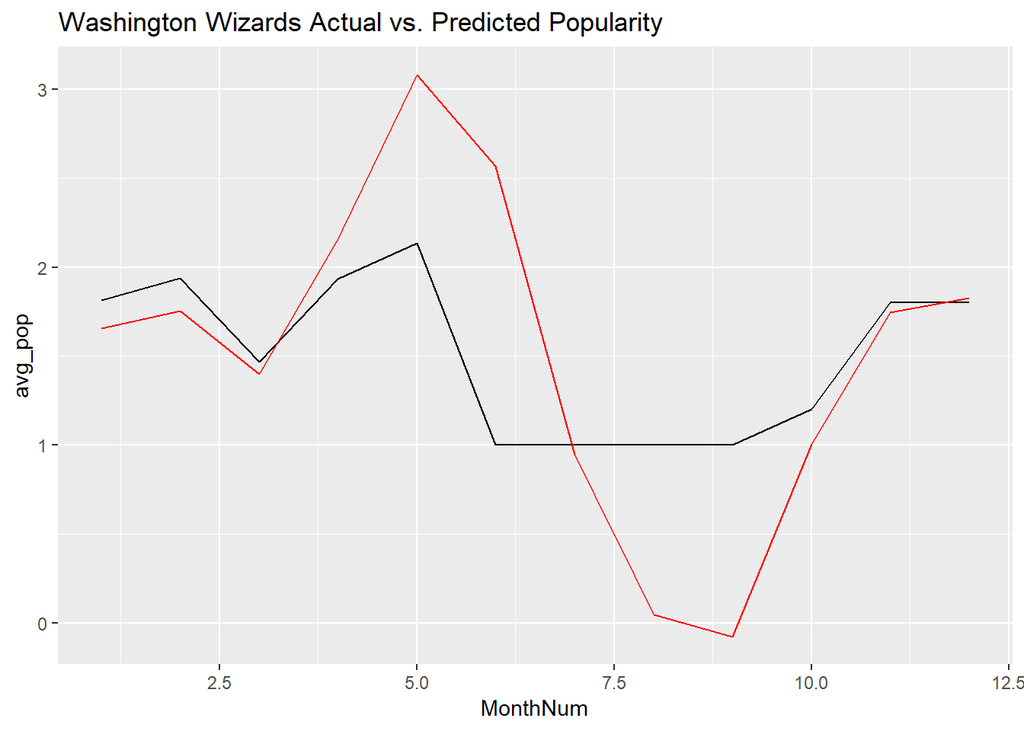

```r
NBATeams %>%
  filter(Team == "WashingtonWizards") %>%
  group_by(MonthNum) %>%
  summarize(avg_pop = mean(Popularity), pred = mean(pred)) %>%
  ggplot() + geom_line(aes(x = MonthNum, y = avg_pop)) + geom_line(aes(x = MonthNum, y = pred), col = "red") +
  ggtitle("Washington Wizards Actual vs. Predicted Popularity")
```

Here, we have fit a very basic linear model that attempts to predict popularity score, using month of the year and team as predictors. From the resuts of this model, we see that the months of May, June, July, August, September, and October are all significant predictors of popularity score. The coefficients for the months of May and June are both positive, which indicates that these months are associated with an increase in popularity score. This makes sense because the months of May and June are when the NBA Playoffs come to a close, and the NBA Finals typically begin towards the end of May. Contrastly, the months of July, August, September, and October all have negative coefficients, indicating that these months are associated with decreases in popularity score. This also makes sense because these months all encompass the NBA offseason, in which no NBA games are played. There is not much going on in the NBA during these times aside from free agency and training camps, so we expect a decrese in search popularity throughout the NBA during these months.